# 4 Tuning hyper-parameters

In ?sec-gradientdescent, we represented the testing and training loss of a model as a function of the number of gradient descent steps we had made. This sort of representation is very useful to figure out how well our model is learning, and is called, appropriately enough, a learning curve. We further discussed that the learning rate (and possibly the regularization rate), and the number of epochs, where *hyper*-parameters of the model. An hyper-parameter is usually defined as a parameter of the model that is *controlling* the learning process, but is not itself modified through learning (Yang & Shami 2020). Hyper-parameters usually need to be determined *before* the training starts (Claesen & De Moor 2015), but there are various strategies to optimize them. In this chapter, we will produce learning curves to find the optimal values of an hyper-parameter of the model we developed in Chapter 2 and Chapter 3 (the threshold at which we consider that a probability is high enough to be considered a positive prediction).

We will illustrate this using an approach called moving-threshold classification, and additionally discuss how we can conduct searches to tune several hyper-parameters at once. There are many techniques to sample multiple parameters at the same time, including Latin hypercube sampling (Huntington & Lyrintzis 1998), successive halvings (Jamieson & Talwalkar 2016), orthogonal sampling (McKay *et al.* 1979), and grid searches. The common point to all of these approaches are that they generate a combination of hyper-parameters, which are used to train the model, and measures of performance are then used to pick the best possible combination of hyper-parameters. In the process of doing this, we will also revisit the question of why the MCC is a good measure of the classification performance, as well as examine tools to investigate the “right” balance between false/true positive rates. At the end of this chapter, we will have produced a very good model for the distribution of the Corsican nuthatch, which we will then *explain* in ?sec-explanations.

## 4.1 Classification based on probabilities

When first introducing classification in Chapter 2 and Chapter 3, we used a model that returned a deterministic answer, which is to say, the name of a class (in our case, this class was either “present” or “absent”). But a lot of classifiers return quantitative values, that correspond to (proxies for) the probability of the different classes. Nevertheless, because we are interested in solving a classification problem, we need to end up with a confusion table, and so we need to turn a number into a class. In the context of binary classification (we model a yes/no variable), this can be done using a threshold for the probability.

Note that the quantitative value returned by the classifier does not *need* to be a probability; it simply needs to be on an interval (or ratio) scale.

The idea behind the use of thresholds is simple: if the classifier output $\hat y$ is larger than (or equal to) the threshold value $\tau$, we consider that this prediction corresponds to the positive class (the event we want to detect, for example the presence of a species). In the other case, this prediction corresponds to the negative class. Note that we do not, strictly, speaking, require that the value $\hat y$ returned by the classifier be a probability. We can simply decide to pick $\tau$ somewhere in the support of the distribution of $\hat y$.

The threshold to decide on a positive event is an hyper-parameter of the model. In the NBC we built in Chapter 2, our decision rule was that $p(+) > p(-)$, which when all is said and done (but we will convince ourselves of this in Section 4.4.1), means that we used $\tau = 0.5$. But there is no reason to assume that the threshold needs to be one half. Maybe the model is overly sensitive to negatives. Maybe there is a slight issue with our training data that bias the model predictions. And for this reason, we have to look for the optimal value of $\tau$.

### 4.1.1 The ROC curve

The ROC curve can be used to rule out a model that performs worse than the no-skill classifier.

We have just described the Receiver Operating Characteristic (ROC; Fawcett (2006)) curve! The ROC curve visualizes the false positive rate on the $x$ axis, and the true positive rate on the $y$ axis. The area under the curve (the ROC-AUC) is a measure of the overall performance of the classifier (Hanley & McNeil 1982); a model with ROC-AUC of 0.5 performs at random, and values moving away from 0.5 indicate better (close to 1) or worse (close to 0) performance. The ROC curve is a description of the model performance across all of the possible threshold values we investigated!

### 4.1.2 The PR curve

One very common issue with ROC curves, is that they are overly optimistic about the performance of the model, especially when the problem we work on suffers from class imbalance, which happens when observations of the positive class are much rarer than observations of the negative class. In ecology, this is a common feature of data on species interactions (Poisot *et al.* 2023). In addition, although a good model will have a high ROC-AUC, a bad model can get a high ROC-AUC too (Halligan *et al.* 2015); this means that ROC-AUC alone is not enough to select a model.

An alternative to ROC is the PR (for precision-recall) curve, in which the positive predictive value is plotted against the true-positive rate; in other words, the PR curve (and therefore the PR-AUC) quantify whether a classifier makes reliable positive predictions, both in terms of these predictions being associated to actual positive outcomes (true-positive rate) and not associated to actual negative outcomes (positive predictive value). Because the PR curve uses the positive predictive values, it captures information that is similar to the ROC curve, but is in general more informative (Saito & Rehmsmeier 2015).

### 4.1.3 The TPTS curve

Becker *et al.* (2022) developed a variant of the ROC curve meant to be used when the validation data are *only* composed of the predictive class; there are a number of situations when this is a reasonable assumption. In the original article, the testing data were reported positive detection of beta-coronaviruses in bat species, which can be seen as a positive-only event since negative tests are unlikely to be reported [the “file-drawer effect”; Pautasso (2010)]. In this context, evaluating the model by accounting for negative testing data introduces biases, as we do not have access to novel negative instances.

## 4.2 A note on cross-entropy loss

In ?sec-gradientdescent, we used loss functions to measure the progress of our learning algorithm. Unsurprisingly, loss functions exist for classification tasks too. One of the most common is the cross-entropy (or log-loss), which is defined at the scale of each prediction as

$$L_i = −\left[y_i \times \text{log}\ p_i+(1−y_i)\times \text{log}\ (1−p_i)\right] \,,
\tag{4.1}$$

where $y_i$ is the actual class, and $p_i$ is the probability associated to the positive class for an input $x_i$. The loss of a model is simply the average of the contributions of individual points. Note that the log-loss is very similar to Shannon’s measure of entropy, and in fact can be expressed based on the Kullback-Leibler divergence of the distributions of $y$ and $p$. All of this is to say say that the cross-entropy loss measures how much information about $y$ is conveyed by $p$.

In this chapter, we use measures like the MCC that describe the performance of a classifier when the predictions are done, but log-loss is useful when there are multiple epochs of training. Neural networks used for classification commonly use log-loss as a loss function; note that the gradient of the log-loss function is very easy to calculate, and that gives it its usefulness as a measure of the advancement of the learning process.

As a gentle introduction to what’s next in this chapter, we can start using the loss to optimize the training process. Most things related to cross-validation *are* hyper-parameters, in that they will regulate our ability to conduct the training process under the best possible conditions. In this section, we will revisit the cross-validation of the model, by investigating how the choice of cross-validation can lead to adverse outcomes. In Figure 4.1, we show how increasing the proportion of datasets retained for model evaluations using holdout cross-validation ?sec-crossvalidation-holdout can change our ability to produce a good model.

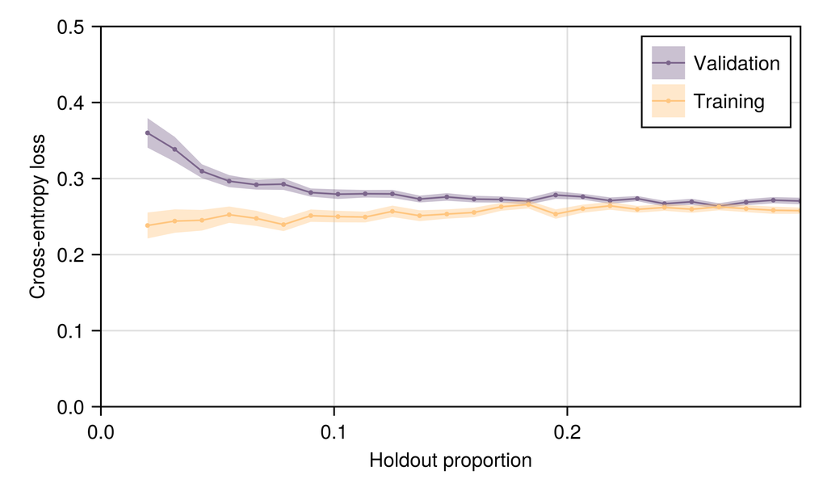

Remember from ?sec-crossvalidation-kfolds that with k-fold, $k$ is an hyper-parameter; it can be tuned in the exact same way! The value of $k$ used in these chapters has been picked because it gives adequate performance.

This simple example served as an illustration of what a learning curve looks like. In the rest of this chapter, we will focus on tuning an hyper-parameter from the model itself (the probability threshold for attribution of the positive class), and see how we can re-construct a general approach from thinking about the components of the confusion table.

## 4.3 How to optimize the threshold?

In order to understand the optimization of the threshold, we first need to understand how a model with thresholding works. When we run such a model on multiple input features, it will return a list of probabilities, for example $[0.2, 0.8, 0.1, 0.5, 1.0]$. We then compare all of these values to an initial threshold, for example $\tau = 0.05$, giving us a vector of Boolean values, in this case $[+, +, +, +, +]$. We can then compare this classified output to a series of validation labels, *e.g.* $[-, +, -, -, +]$, and report the performance of our model. In this case, the very low thresholds means that we accept any probability as a positive case, and so our model is very strongly biased (towards false positives). We then increase the threshold, and start again.

As we have discussed in Section 4.1, moving the threshold is essentially a way to move in the space of true/false rates. As the measures of classification performance capture information that is relevant in this space, there should be a value of the threshold that maximizes one of these measures. Alas, no one agrees on which measure this should be (Perkins & Schisterman 2006; Unal 2017). The usual recommendation is to use the True Skill Statistic, also known as Youden’s $J$ (Youden 1950). The biomedical literature, which is quite naturally interested in getting the interpretation of tests right, has established that maximizing this value brings us very close to the optimal threshold for a binary classifier (Perkins & Schisterman 2005). In a simulation study, using the True Skill Statistic gave good predictive performance for models of species interactions (Poisot 2023).

Some authors have used the MCC as a measure of optimality (Zhou & Jakobsson 2013), as it is maximized *only* when a classifier gets a good score for the basic rates of the confusion matrix. Based on this information, Chicco & Jurman (2023) recommend that MCC should be used to pick the optimal threshold *regardless of the question*, and I agree with their assessment. A high MCC is always associated to a high ROC-AUC, TSS, etc., but the opposite is not necessarily true. This is because the MCC can only reach high values when the model is good at *everything*, and therefore it is not possible to trick it. In fact, previous comparisons show that MCC even outperform measures of classification loss (Jurman *et al.* 2012).

For once, and after over 15 years of methodological discussion, it appears that we have a conclusive answer! In order to pick the optimal threshold, we find the value that maximizes the MCC. Note that in previous chapters, we already used the MCC as a our criteria for the best model, and now you know why.

## 4.4 Application: improved Corsican nuthatch model

In this section, we will finish the training of the model for the distribution of *Sitta whiteheadi*, by picking optimal hyper-parameters, and finally reporting its performance on the testing dataset. At the end of this chapter, we will therefore have established a trained model, that we will use in ?sec-explanations to see how each prediction emerges.

### 4.4.1 Making the NBC explicitly probabilistic

In Chapter 2, we have expressed the probability that the NBC recommends a positive outcome as

$$P(+|x) = \frac{P(+)}{P(x)}P(x|+)\,,$$

and noted that because $P(x)$ is constant across all classes, we could simplify this model as $P(+|x) \propto P(+)P(x|+)$. But because we know the only two possible classes are $+$ and $-$, we can figure out the expression for $P(x)$. Because we are dealing with probabilities, we know that $P(+|x)+P(-|x) = 1$. We can therefore re-write this as

$$\frac{P(+)}{P(x)}P(x|+)+\frac{P(-)}{P(x)}P(x|-) = 1\,$$

which after some reorganization (and note that $P(-) = 1-P(+)$), results in

$$P(x) = P(+) P(x|+)+P(-) P(x|-) \,.$$

This value $P(x)$ is the “evidence” in Bayesian parlance, and we can use this value explicitly to get the prediction for the probability associated to the class $+$ using the NBC.

Note that we can see that using the approximate version we used so far (the prediction is positive if $P(+) P(x|+) > P(-) P(x|-)$) is equivalent to saying that the prediction is positive whenever $P(+|x) > \tau$ with $\tau = 0.5$. In the next sections, we will challenge the assumption that $0.5$ is the optimal value of $\tau$.

In Figure 4.2, we show the effect of moving the threshold from 0 to 1 on the value of the MCC. This figure reveals that the value of the threshold that maximizes the average MCC across folds is $\tau \approx 0\.573$. But more importantly, it seems that the “landscape” of the MCC around this value is relatively flat – in other words, as long as we do not pick a threshold that is too outlandishly low (or high!), the model would have a good performance. It is worth pausing for a minute and questioning *why* that is.

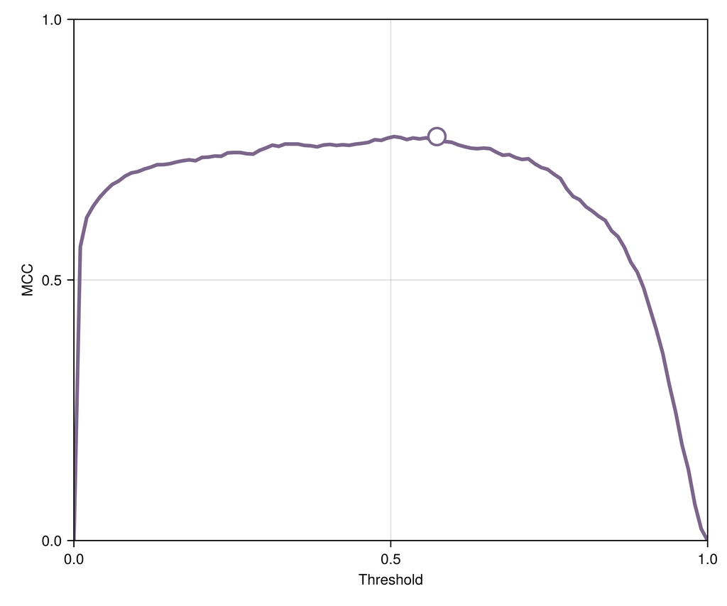

To do so, we can look at the distribution of probabilities returned by the NBC, which are presented in Figure 4.3. It appears that the NBC is often confident in its recommendations, with a bimodal distribution of probabilities. For this reason, small changes in the position of the threshold would only affect a very small number of instances, and consequently only have a small effect on the MCC and other statistics. If the distribution of probabilities returned by the NBC had been different, the shape of the learning curve may have been a lot more skewed.

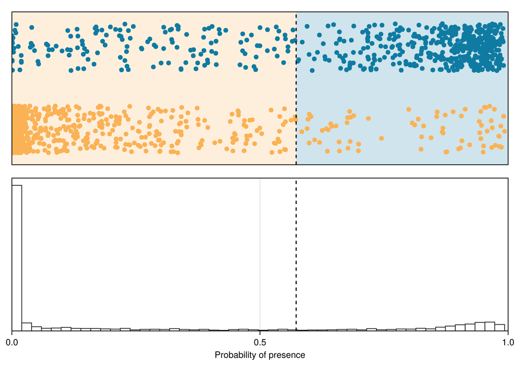

Figure 4.3: Probabilities assigned to each pixel (bottom), color-coded by their value in the validation set (top scatterplots). The NBC is making a lot of recommendations very close to 0 or very close to 1, and for this reason, positioning the threshold anywhere in the middle of the range would give almost similar results in terms of the MCC.

Looking at Figure 4.3, it appears that changing the threshold is changing the proportion of false positives and negatives; it is worth investigating exactly how this happens. We can explore this behavior in Figure 4.4. The points where the PPV and NPC curves meet is a good first approximation of the threshold (the MCC is not picking this exact point, but this is an approximation nonetheless).

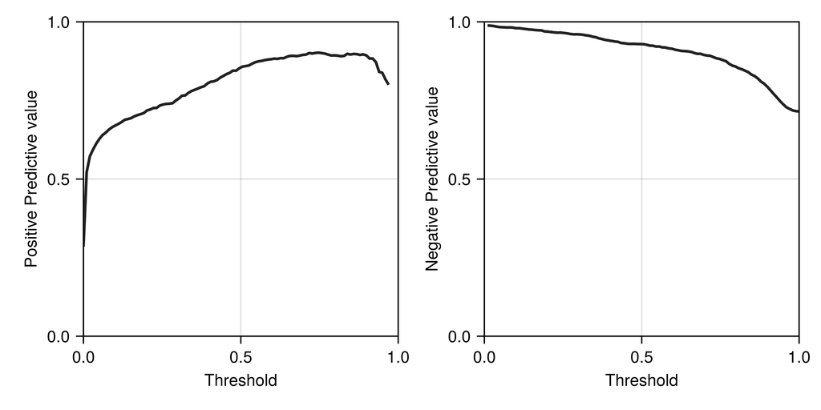

### 4.4.2 How good is the model?

After picking a threshold and seeing how it relates to the distribution of probabilities in the model output, we can have a look at the ROC and PR curves. They are presented in Figure 4.5. In both cases, we see that the model is behaving correctly (it is nearing the point in the graph corresponding to perfect classifications), and importantly, we can check that the variability between the different folds is low. The model also outperforms the no-skill classifier. Taken together, these results give us a strong confidence in the fact that our model with the threshold applied represents an improvement over the version without the threshold.

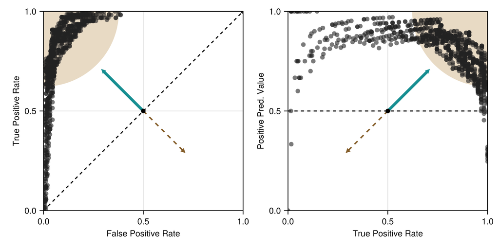

In a sense, the ROC and PR curves are another projection of the results from Figure 4.4: a good classifier makes credible recommendations for its positive class, while maintaining credible recommendations for the negative class. Looking at several ways to express the performance of the classifier is a good idea, as a good understanding of how reliable our predicitions are depends on our ability to appraise these different sources of error.

### 4.4.3 Optimizing the prior

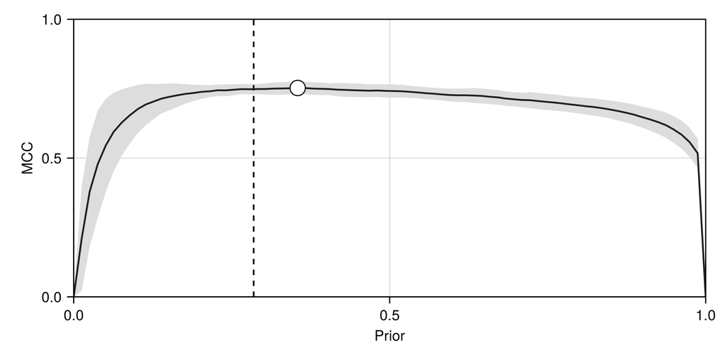

### 4.4.4 Testing and visualizing the final model

As we are now considering that our model is adequately trained, we can apply it to the testing data we had set aside early in Chapter 2. Applying the trained model to this data provides a fair estimate of the expected model performance, and relaying this information to people who are going to use the model is important.

We are *not* applying the older versions of the model to the testing data, as we had decided against this. We had established the rule of “we pick the best model as the one with the highest validation MCC”, and this is what we will stick to. To do otherwise would be the applied machine learning equivalent of $p$-hacking, as the question of “what to do in case a model with lower validation MCC had a better performance on the testing data?” would arise, and we do not want to start questioning our central decision this late in the process.

We can start by taking a look at the confusion matrix on the testing data:

$$\begin{pmatrix}
123 & 17 \\
39 & 380
\end{pmatrix}$$

The final predictions are shown in Figure 4.7. Although the range map is very similar to the one we produced by the end of Chapter 3, the small addition of an optimized threshold leads to a model that is overall a little more accurate. In ?sec-bagging, we will focus on the uncertainty associated to this prediction.

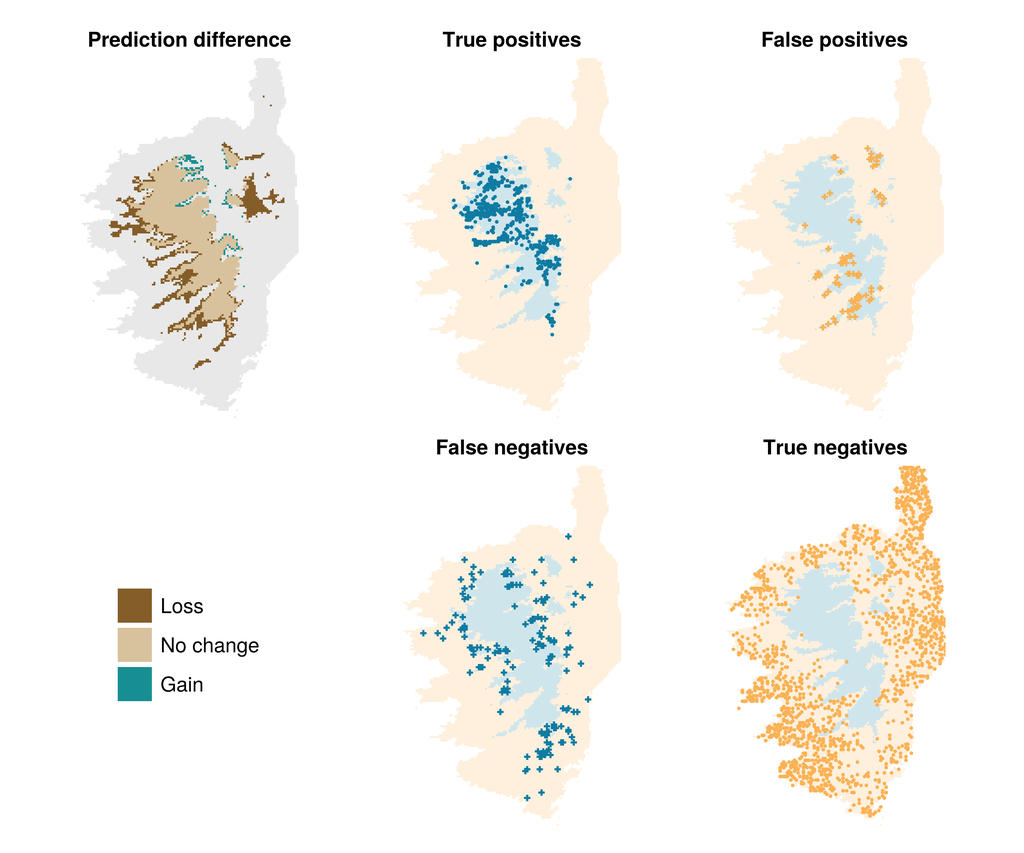

## 4.5 Conclusion

In this chapter, we have refined a model by adopting a principled approach to establishing hyper-parameters. This resulted in a final trained model, which we applied to produce the final prediction of the distribution of *Sitta whiteheadi*. In ?sec-explanations, we will start asking “why”? Specifically, we will see a series of tools to evaluate why the model was making a specific prediction at a specific place, and look at the relationship between the importance of variables for model performance and for actual predictions. But before we do this, we will spend time in ?sec-bagging to discuss the uncertainty that is part of this model, and how it can be communicated.

# References

Becker, D.J., Albery, G.F., Sjodin, A.R., Poisot, T., Bergner, L.M., Chen, B., *et al.* (2022). Optimising predictive models to prioritise viral discovery in zoonotic reservoirs. *The Lancet Microbe*, 3, e625–e637.

Chicco, D. & Jurman, G. (2023). [The Matthews correlation coefficient (MCC) should replace the ROC AUC as the standard metric for assessing binary classification](https://doi.org/10.1186/s13040-023-00322-4). *BioData Mining*, 16.

Claesen, M. & De Moor, B. (2015). [Hyperparameter search in machine learning](https://doi.org/10.48550/ARXIV.1502.02127).

Fawcett, T. (2006). [An introduction to ROC analysis](https://doi.org/10.1016/j.patrec.2005.10.010). *Pattern Recognition Letters*, 27, 861–874.

Halligan, S., Altman, D.G. & Mallett, S. (2015). [Disadvantages of using the area under the receiver operating characteristic curve to assess imaging tests: A discussion and proposal for an alternative approach](https://doi.org/10.1007/s00330-014-3487-0). *European Radiology*, 25, 932–939.

Hanley, J.A. & McNeil, B.J. (1982). [The meaning and use of the area under a receiver operating characteristic (ROC) curve.](https://doi.org/10.1148/radiology.143.1.7063747) *Radiology*, 143, 29–36.

Huntington, D.E. & Lyrintzis, C.S. (1998). Improvements to and limitations of Latin hypercube sampling. *Probabilistic Engineering Mechanics*, 13, 245–253.

Jamieson, K. & Talwalkar, A. (2016). [Non-stochastic best arm identification and hyperparameter optimization](https://proceedings.mlr.press/v51/jamieson16.html). In: *Proceedings of the 19th international conference on artificial intelligence and statistics*, Proceedings of machine learning research (eds. Gretton, A. & Robert, C.C.). PMLR, Cadiz, Spain, pp. 240–248.

Jurman, G., Riccadonna, S. & Furlanello, C. (2012). [A Comparison of MCC and CEN Error Measures in Multi-Class Prediction](https://doi.org/10.1371/journal.pone.0041882). *PLoS ONE*, 7, e41882.

McKay, M.D., Beckman, R.J. & Conover, W.J. (1979). [A comparison of three methods for selecting values of input variables in the analysis of output from a computer code](https://doi.org/10.2307/1268522). *Technometrics*, 21, 239.

Pautasso, M. (2010). [Worsening file-drawer problem in the abstracts of natural, medical and social science databases](https://doi.org/10.1007/s11192-010-0233-5). *Scientometrics*, 85, 193–202.

Perkins, N.J. & Schisterman, E.F. (2005). [The Youden Index and the Optimal Cut-Point Corrected for Measurement Error](https://doi.org/10.1002/bimj.200410133). *Biometrical Journal*, 47, 428–441.

Perkins, N.J. & Schisterman, E.F. (2006). [The Inconsistency of “Optimal” Cutpoints Obtained using Two Criteria based on the Receiver Operating Characteristic Curve](https://doi.org/10.1093/aje/kwj063). *American Journal of Epidemiology*, 163, 670–675.

Poisot, T. (2023). [Guidelines for the prediction of species interactions through binary classification](https://doi.org/10.1111/2041-210x.14071). *Methods in Ecology and Evolution*, 14, 1333–1345.

Poisot, T., Ouellet, M.-A., Mollentze, N., Farrell, M.J., Becker, D.J., Brierley, L., *et al.* (2023). [Network embedding unveils the hidden interactions in the mammalian virome](https://doi.org/10.1016/j.patter.2023.100738). *Patterns*, 4, 100738.

Saito, T. & Rehmsmeier, M. (2015). [The Precision-Recall Plot Is More Informative than the ROC Plot When Evaluating Binary Classifiers on Imbalanced Datasets](https://doi.org/10.1371/journal.pone.0118432). *PLOS ONE*, 10, e0118432.

Unal, I. (2017). [Defining an Optimal Cut-Point Value in ROC Analysis: An Alternative Approach](https://doi.org/10.1155/2017/3762651). *Computational and Mathematical Methods in Medicine*, 2017, 1–14.

Yang, L. & Shami, A. (2020). [On hyperparameter optimization of machine learning algorithms: Theory and practice](https://doi.org/10.1016/j.neucom.2020.07.061). *Neurocomputing*, 415, 295–316.

Youden, W.J. (1950). Index for rating diagnostic tests. *Cancer*, 3, 32–35.

Zhou, H. & Jakobsson, E. (2013). [Predicting Protein-Protein Interaction by the Mirrortree Method: Possibilities and Limitations](https://doi.org/10.1371/journal.pone.0081100). *PLoS ONE*, 8, e81100.